# test

Nicholas Nagle

January 26, 2015

# INSTRUCTIONS:

Edit this file by replacing the instructions with text and code to anser the questions. I should be able to knit this file and reproduce the html, pdf, or word document.

A block to load in the data:

```r
library(ggplot2)
rm(list=ls()) # Clean the workspace to be empty
arbuthnot <- read.csv('~/Desktop/Geog 415/sselecm2/homework1/data/arbuthnot.csv')
```

# Question 1

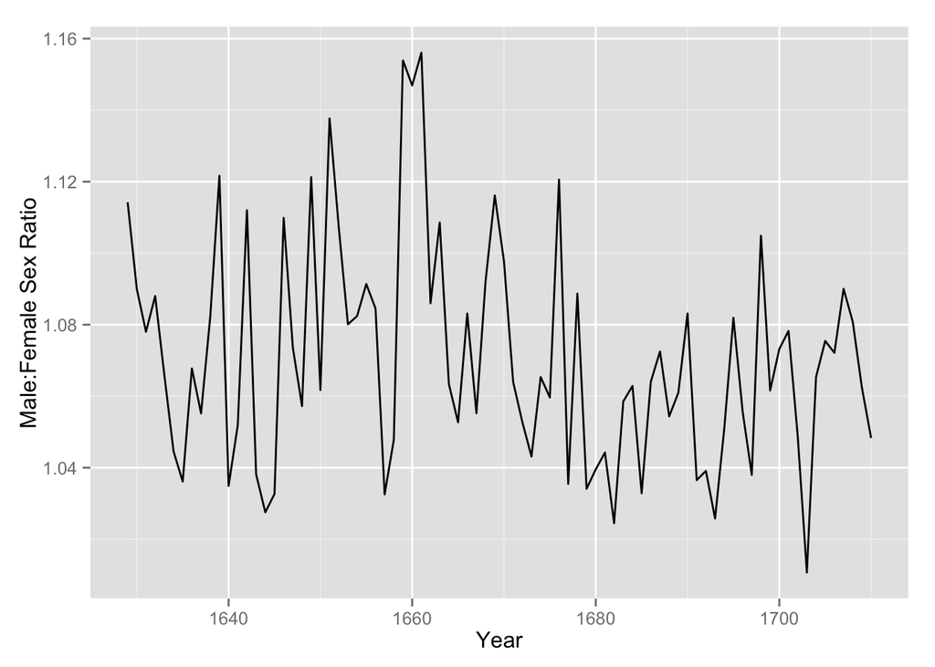

```r
ggplot(data=arbuthnot) +
  geom_line(aes(x=Year, y=Males/Females))+
  ylab('Male:Female Sex Ratio')
```

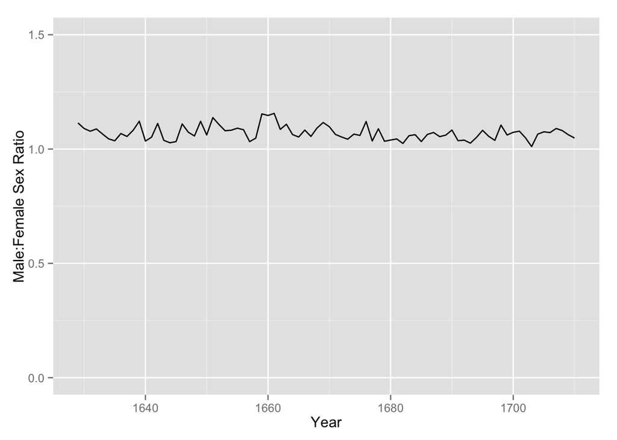

```r
  ggplot(data=arbuthnot) +
  geom_line(aes(x=Year, y=Males/Females))+
  scale_y_continuous(limits=c(0, 1.5)) +
  ylab('Male:Female Sex Ratio')
```

#The first plot seems to have many “ups and downs” while the second plot looks more simple with smaller undulations. They do not “feel” like they are describing the same data. #You can mislead readers by changing the scaling on a graph very easily. By changing the scaling you can skew your data results whichever way you want them to appear. For instance if you chnage the x-axis to have data results by 100’s instead of 10’s, your graph will look a lot different. #The plot that seems more appropriate to me is the defualt plot. The reason I think this plot is more appropriate is because it is more detailed. The y-axis does not go all the way to zero, and it shows the male:female sex ratio with more precision than the other plot.

# Question 2

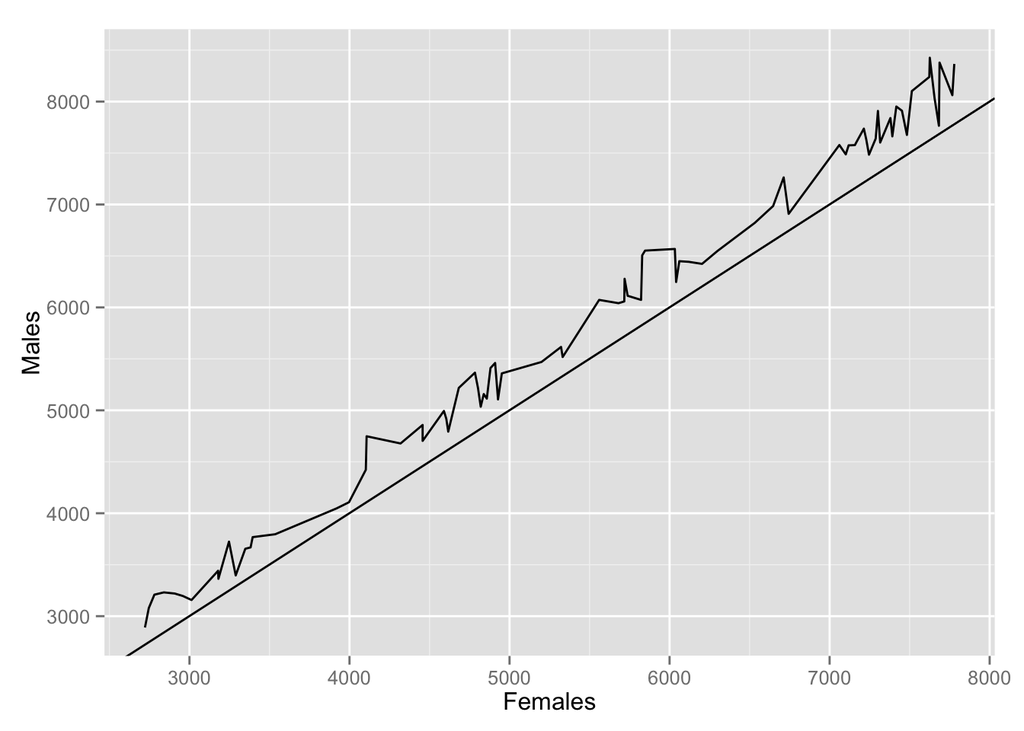

```r
ggplot(data=arbuthnot)+geom_line(aes(x=Females, y=Males))+geom_abline(intercept=1, slope=1)
```

#Based on the scatter plot showing male and female christenings, we can see that more males are christened than females. By looking at the 45 degree line which shows equal male and female christenings, we notice that there are no points on this line that show male and female christening values to be equal. All of the values are above the 45 degree line, showing that there are more male christening values than female.

# Question 3

#I think the christenings-based sample would be similar to the births-based sample because most people in that time period had their babies christened. I think this fact is important because if someone were to have a baby they would most likely have their baby christened which would be a good representation for births. #In my opinion I don’t think a christenings based sample would be appropriate now in the 21st century. I think now in modern time many people have a wide array of belief systems so if somebody were to have a baby, they might not get it christened because of their religious view. Also, I think gender selective abortions and gendercide play a huge part in the sex ratio.

# Question 4

#Sex ratio at birth means how many males born there are to females born. This is usually out of 100 females born. The sex ratio depends on many factors. Some of those factors include natural causes, sex-selective abortion, and gendercide. Considering the three cases listed, each one probably has a different sex ratio because of different causes. In late 17th century England, I think the sex ratio was based mostly on biological and natural factors. In the US during the 21st century a big factor impacting the sex ratio is sex-selective abortion, while China in the 21st century is heavily impacted by gendercide.

# Question 5

#59.5 in and 69.5 in

# Question 6

#x bar is the mean of x, while x_i is the individual value of x and N is the number of data points. By using this equation for the sample variance, you can measure how far a set of numbers is spread out from the expected value.